# Entrenamiento Manual de una Red Neuronal: El Problema XOR

# Automatización en R — 10 a 20 épocas

## Concepto: Por qué automatizar

Repetir los cálculos manuales 20 veces sería tedioso y propenso a errores. La automatización permite:

1. Ejecutar muchas épocas rápidamente
2. Garantizar que cada paso aplica exactamente las mismas fórmulas
3. Registrar el historial completo para graficar y analizar

## Implementación desde cero

```r
# ============================================================
# ENTRENAMIENTO AUTOMATIZADO — SIN LIBRERÍAS DE ML
# ============================================================

entrenar_xor_1obs <- function(
    x1_in, x2_in, y_in,          # Observación de entrenamiento
    w1_0, w2_0, w3_0, w4_0,      # Pesos iniciales (capa oculta)
    w5_0, w6_0,                   # Pesos iniciales (capa salida)
    b1_0 = 0, b2_0 = 0, b3_0 = 0, # Sesgos iniciales
    alpha = 0.25,                  # Tasa de aprendizaje
    n_epocas = 20                  # Número de épocas
) {

  # Inicializar pesos
  w1 <- w1_0; w2 <- w2_0; w3 <- w3_0; w4 <- w4_0
  w5 <- w5_0; w6 <- w6_0
  b1 <- b1_0; b2 <- b2_0; b3 <- b3_0

  # Almacenar resultados
  historial <- data.frame()

  for (ep in 1:n_epocas) {

    # --- FORWARD PASS ---
    z1   <- w1*x1_in + w3*x2_in + b1
    z2   <- w2*x1_in + w4*x2_in + b2
    h1   <- sigmoid(z1)
    h2   <- sigmoid(z2)
    z3   <- w5*h1 + w6*h2 + b3
    yhat <- sigmoid(z3)
    E    <- loss(y_in, yhat)

    # --- BACKPROPAGATION ---
    # Error local en la capa de salida
    delta3 <- grad_loss(y_in, yhat) * sigmoid_deriv(yhat)

    # Gradientes de la capa de salida
    dE_dw5 <- delta3 * h1
    dE_dw6 <- delta3 * h2
    dE_db3 <- delta3

    # Error local en la capa oculta
    delta1 <- delta3 * w5 * sigmoid_deriv(h1)
    delta2 <- delta3 * w6 * sigmoid_deriv(h2)

    # Gradientes de la capa oculta
    dE_dw1 <- delta1 * x1_in
    dE_dw3 <- delta1 * x2_in
    dE_dw2 <- delta2 * x1_in
    dE_dw4 <- delta2 * x2_in
    dE_db1 <- delta1
    dE_db2 <- delta2

    # Magnitud del gradiente total
    grad_mag <- sqrt(dE_dw1^2 + dE_dw2^2 + dE_dw3^2 + dE_dw4^2 +
                     dE_dw5^2 + dE_dw6^2)

    # --- ACTUALIZACIÓN DE PARÁMETROS ---
    w1 <- w1 - alpha * dE_dw1
    w2 <- w2 - alpha * dE_dw2
    w3 <- w3 - alpha * dE_dw3
    w4 <- w4 - alpha * dE_dw4
    w5 <- w5 - alpha * dE_dw5
    w6 <- w6 - alpha * dE_dw6
    b1 <- b1 - alpha * dE_db1
    b2 <- b2 - alpha * dE_db2
    b3 <- b3 - alpha * dE_db3

    # Guardar fila del historial
    historial <- rbind(historial, data.frame(
      Epoca    = ep,
      z1       = round(z1,   5),
      z2       = round(z2,   5),
      z3       = round(z3,   5),
      h1       = round(h1,   5),
      h2       = round(h2,   5),
      y_hat    = round(yhat, 5),
      y        = y_in,
      Err_abs  = round(abs(y_in - yhat), 5),
      Costo    = round(E,    5),
      Grad_mag = round(grad_mag, 6),
      w1       = round(w1, 5), w2 = round(w2, 5),
      w3       = round(w3, 5), w4 = round(w4, 5),
      w5       = round(w5, 5), w6 = round(w6, 5),
      b1       = round(b1, 5), b2 = round(b2, 5),
      b3       = round(b3, 5)
    ))
  }

  return(historial)
}

# Ejecutar con los parámetros del ejemplo de clase
set.seed(42)
hist_orig <- entrenar_xor_1obs(
  x1_in = 0, x2_in = 1, y_in = 1,
  w1_0 = 0.1,  w2_0 = 0.5,  w3_0 = -0.7, w4_0 = 0.3,
  w5_0 = 0.2,  w6_0 = 0.4,
  alpha = 0.25, n_epocas = 20
)
```

## Tabla completa de resultados

```r
knitr::kable(
  hist_orig[, c("Epoca","z1","z2","z3","h1","h2",
                "y_hat","y","Err_abs","Costo","Grad_mag")],
  col.names = c("Época","z1","z2","z3","h1","h2",
                "ŷ","y","|y-ŷ|","Costo","||∇E||"),
  digits = 5,
  caption = "Tabla completa: 20 épocas de entrenamiento con una observación XOR")
```

Tabla completa: 20 épocas de entrenamiento con una observación XOR

| Época | z1 | z2 | z3 | h1 | h2 | ŷ | y | \|y-ŷ\| | Costo | \|\|∇E\|\| |
| --- | --- | --- | --- | --- | --- | --- | --- | --- | --- | --- |
| 1 | -0.70000 | 0.30000 | 0.29614 | 0.33181 | 0.57444 | 0.57350 | 1 | 0.42650 | 0.09095 | 0.07011 |
| 2 | -0.69769 | 0.30510 | 0.33432 | 0.33233 | 0.57569 | 0.58281 | 1 | 0.41719 | 0.08702 | 0.06837 |
| 3 | -0.69534 | 0.31024 | 0.37154 | 0.33285 | 0.57694 | 0.59183 | 1 | 0.40817 | 0.08330 | 0.06665 |
| 4 | -0.69296 | 0.31541 | 0.40780 | 0.33337 | 0.57821 | 0.60056 | 1 | 0.39944 | 0.07978 | 0.06497 |
| 5 | -0.69056 | 0.32060 | 0.44313 | 0.33391 | 0.57947 | 0.60901 | 1 | 0.39099 | 0.07644 | 0.06331 |
| 6 | -0.68815 | 0.32579 | 0.47754 | 0.33445 | 0.58073 | 0.61717 | 1 | 0.38283 | 0.07328 | 0.06169 |
| 7 | -0.68572 | 0.33098 | 0.51106 | 0.33499 | 0.58200 | 0.62505 | 1 | 0.37495 | 0.07029 | 0.06011 |
| 8 | -0.68329 | 0.33615 | 0.54370 | 0.33553 | 0.58326 | 0.63267 | 1 | 0.36733 | 0.06746 | 0.05856 |
| 9 | -0.68085 | 0.34131 | 0.57548 | 0.33607 | 0.58451 | 0.64003 | 1 | 0.35997 | 0.06479 | 0.05706 |
| 10 | -0.67842 | 0.34644 | 0.60644 | 0.33661 | 0.58575 | 0.64713 | 1 | 0.35287 | 0.06226 | 0.05560 |
| 11 | -0.67599 | 0.35154 | 0.63659 | 0.33716 | 0.58699 | 0.65398 | 1 | 0.34602 | 0.05986 | 0.05418 |
| 12 | -0.67357 | 0.35660 | 0.66596 | 0.33770 | 0.58822 | 0.66060 | 1 | 0.33940 | 0.05760 | 0.05280 |
| 13 | -0.67115 | 0.36162 | 0.69456 | 0.33824 | 0.58943 | 0.66698 | 1 | 0.33302 | 0.05545 | 0.05147 |
| 14 | -0.66875 | 0.36660 | 0.72244 | 0.33878 | 0.59064 | 0.67314 | 1 | 0.32686 | 0.05342 | 0.05018 |
| 15 | -0.66637 | 0.37153 | 0.74960 | 0.33931 | 0.59183 | 0.67909 | 1 | 0.32091 | 0.05149 | 0.04893 |
| 16 | -0.66400 | 0.37641 | 0.77608 | 0.33984 | 0.59301 | 0.68483 | 1 | 0.31517 | 0.04966 | 0.04772 |
| 17 | -0.66165 | 0.38124 | 0.80189 | 0.34037 | 0.59417 | 0.69038 | 1 | 0.30962 | 0.04793 | 0.04655 |
| 18 | -0.65931 | 0.38601 | 0.82706 | 0.34089 | 0.59532 | 0.69573 | 1 | 0.30427 | 0.04629 | 0.04542 |
| 19 | -0.65700 | 0.39073 | 0.85161 | 0.34141 | 0.59646 | 0.70091 | 1 | 0.29909 | 0.04473 | 0.04433 |
| 20 | -0.65471 | 0.39539 | 0.87557 | 0.34193 | 0.59758 | 0.70590 | 1 | 0.29410 | 0.04325 | 0.04327 |

> **Análisis** La predicción $\hat{y}$ aumenta monótonamente desde ~0.57 hacia 1, el costo disminuye en cada época y la magnitud del gradiente también decrece, lo que indica que el algoritmo converge correctamente. La tasa de mejora es pequeña por época porque la tasa de aprendizaje $\alpha = 0.25$ es conservadora.

# Análisis gráfico del proceso de entrenamiento

## Concepto: ¿Qué nos dicen las gráficas?

Las gráficas permiten observar visualmente cómo evoluciona el aprendizaje:

- **Costo decreciente** → el modelo mejora
- **Error absoluto decreciente** → las predicciones se acercan al objetivo
- **Gradiente decreciente** → el modelo se acerca a un mínimo
- **Pesos convergiendo** → los parámetros se estabilizan

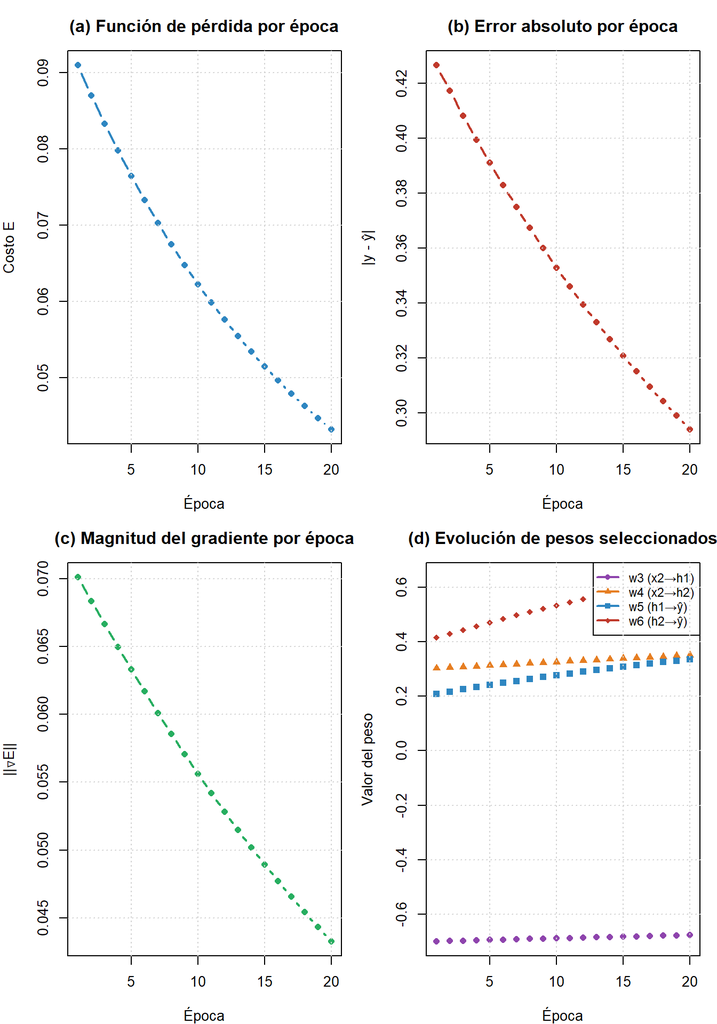

```r
par(mfrow = c(2, 2), mar = c(4, 4, 3, 1))

# --- (a) Costo por época ---
plot(hist_orig$Epoca, hist_orig$Costo,
     type = "b", pch = 16, col = "#2E86C1",
     xlab = "Época", ylab = "Costo E",
     main = "(a) Función de pérdida por época",
     lwd = 2)
grid()

# --- (b) Error absoluto por época ---
plot(hist_orig$Epoca, hist_orig$Err_abs,
     type = "b", pch = 16, col = "#C0392B",
     xlab = "Época", ylab = "|y - ŷ|",
     main = "(b) Error absoluto por época",
     lwd = 2)
grid()

# --- (c) Magnitud del gradiente ---
plot(hist_orig$Epoca, hist_orig$Grad_mag,
     type = "b", pch = 16, col = "#27AE60",
     xlab = "Época", ylab = "||∇E||",
     main = "(c) Magnitud del gradiente por época",
     lwd = 2)
grid()

# --- (d) Evolución de pesos seleccionados ---
plot(hist_orig$Epoca, hist_orig$w3,
     type = "b", pch = 16, col = "#8E44AD",
     xlab = "Época", ylab = "Valor del peso",
     main = "(d) Evolución de pesos seleccionados",
     ylim = range(c(hist_orig$w3, hist_orig$w4,
                    hist_orig$w5, hist_orig$w6)),
     lwd = 2)
lines(hist_orig$Epoca, hist_orig$w4, type="b", pch=17, col="#E67E22", lwd=2)
lines(hist_orig$Epoca, hist_orig$w5, type="b", pch=15, col="#2E86C1", lwd=2)
lines(hist_orig$Epoca, hist_orig$w6, type="b", pch=18, col="#C0392B", lwd=2)
legend("topright",
       legend = c("w3 (x2→h1)", "w4 (x2→h2)", "w5 (h1→ŷ)", "w6 (h2→ŷ)"),
       col    = c("#8E44AD","#E67E22","#2E86C1","#C0392B"),
       pch    = c(16,17,15,18), lwd = 2, cex = 0.85)
grid()
```

```r
par(mfrow = c(1, 1))
```

> **Análisis de las gráficas:**

> **(a) Costo:** Disminuye en cada época, con mayor rapidez al principio y más lentamente al final (curva convexa). Esto es típico del descenso de gradiente: los pasos grandes se dan cuando el gradiente es grande.

> **(b) Error absoluto:** Sigue el mismo patrón que el costo, reduciéndose de ~0.43 a un valor más pequeño. Como usamos la misma observación siempre, la reducción es suave y monótona.

> **(c) Magnitud del gradiente:** Decrece con las épocas, lo que confirma que nos acercamos a un mínimo. Si el gradiente llegara a cero, los pesos dejarían de cambiar (convergencia).

# Sensibilidad a la inicialización

## Concepto: ¿Por qué importa la inicialización?

Los pesos iniciales determinan el punto de partida en el espacio de pérdida. Diferentes inicializaciones pueden llevar a:

- Diferentes velocidades de convergencia
- Diferentes mínimos locales
- Mayor o menor estabilidad en los gradientes

```r
# Nueva inicialización: pesos más grandes y con signos distintos
hist_alt <- entrenar_xor_1obs(
  x1_in = 0, x2_in = 1, y_in = 1,
  w1_0 = 0.9,  w2_0 = -0.5, w3_0 = 0.3,  w4_0 = -0.8,
  w5_0 = -0.4, w6_0 = 0.7,
  alpha = 0.25, n_epocas = 20
)
```

## Comparación visual

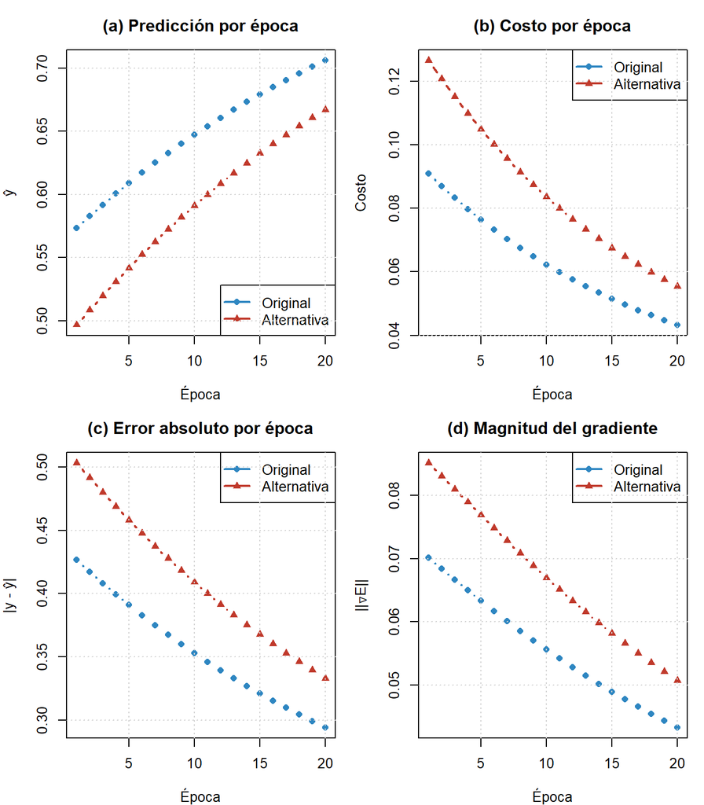

```r
par(mfrow = c(2, 2), mar = c(4, 4, 3, 1))

# --- (a) Predicción ---
plot(hist_orig$Epoca, hist_orig$y_hat,
     type = "b", pch = 16, col = "#2E86C1", lwd = 2,
     xlab = "Época", ylab = "ŷ",
     main = "(a) Predicción por época",
     ylim = range(c(hist_orig$y_hat, hist_alt$y_hat)))
lines(hist_alt$Epoca, hist_alt$y_hat,
      type = "b", pch = 17, col = "#C0392B", lwd = 2)
abline(h = 1, lty = 2, col = "gray50")
legend("bottomright",
       legend = c("Original", "Alternativa"),
       col = c("#2E86C1","#C0392B"), pch = c(16,17), lwd = 2)
grid()

# --- (b) Costo ---
plot(hist_orig$Epoca, hist_orig$Costo,
     type = "b", pch = 16, col = "#2E86C1", lwd = 2,
     xlab = "Época", ylab = "Costo",
     main = "(b) Costo por época",
     ylim = range(c(hist_orig$Costo, hist_alt$Costo)))
lines(hist_alt$Epoca, hist_alt$Costo,
      type = "b", pch = 17, col = "#C0392B", lwd = 2)
legend("topright",
       legend = c("Original", "Alternativa"),
       col = c("#2E86C1","#C0392B"), pch = c(16,17), lwd = 2)
grid()

# --- (c) Error absoluto ---
plot(hist_orig$Epoca, hist_orig$Err_abs,
     type = "b", pch = 16, col = "#2E86C1", lwd = 2,
     xlab = "Época", ylab = "|y - ŷ|",
     main = "(c) Error absoluto por época",
     ylim = range(c(hist_orig$Err_abs, hist_alt$Err_abs)))
lines(hist_alt$Epoca, hist_alt$Err_abs,
      type = "b", pch = 17, col = "#C0392B", lwd = 2)
legend("topright",
       legend = c("Original", "Alternativa"),
       col = c("#2E86C1","#C0392B"), pch = c(16,17), lwd = 2)
grid()

# --- (d) Magnitud del gradiente ---
plot(hist_orig$Epoca, hist_orig$Grad_mag,
     type = "b", pch = 16, col = "#2E86C1", lwd = 2,
     xlab = "Época", ylab = "||∇E||",
     main = "(d) Magnitud del gradiente",
     ylim = range(c(hist_orig$Grad_mag, hist_alt$Grad_mag)))
lines(hist_alt$Epoca, hist_alt$Grad_mag,
      type = "b", pch = 17, col = "#C0392B", lwd = 2)
legend("topright",
       legend = c("Original", "Alternativa"),
       col = c("#2E86C1","#C0392B"), pch = c(16,17), lwd = 2)
grid()
```

```r
par(mfrow = c(1, 1))
```

## Tabla comparativa: Épocas 1, 5, 10 y 20

```r
epocas_clave <- c(1, 5, 10, 20)

df_comp <- data.frame(
  Epoca          = epocas_clave,
  yhat_orig      = hist_orig$y_hat[epocas_clave],
  costo_orig     = hist_orig$Costo[epocas_clave],
  yhat_alt       = hist_alt$y_hat[epocas_clave],
  costo_alt      = hist_alt$Costo[epocas_clave]
)

knitr::kable(df_comp,
  col.names = c("Época", "ŷ (Original)", "Costo (Orig.)",
                "ŷ (Alternativa)", "Costo (Alt.)"),
  digits = 5,
  caption = "Comparación de inicializaciones en épocas clave")
```

Comparación de inicializaciones en épocas clave

| Época | ŷ (Original) | Costo (Orig.) | ŷ (Alternativa) | Costo (Alt.) |
| --- | --- | --- | --- | --- |
| 1 | 0.57350 | 0.09095 | 0.49681 | 0.12660 |
| 5 | 0.60901 | 0.07644 | 0.54188 | 0.10494 |
| 10 | 0.64713 | 0.06226 | 0.59111 | 0.08360 |
| 20 | 0.70590 | 0.04325 | 0.66699 | 0.05545 |

> **Análisis:** La inicialización alternativa parte de una predicción diferente porque los pesos iniciales producen una activación distinta. Dependiendo de qué tan cerca estén los pesos iniciales de una buena solución, la convergencia puede ser más rápida o más lenta. Inicializaciones con pesos grandes pueden causar gradientes más inestables al principio. En la práctica, técnicas como **Xavier** o **He** inicializan los pesos de forma inteligente para acelerar la convergencia.

# Entrenamiento con dos observaciones XOR (forma matricial)

## Concepto: ¿Por qué usar matrices?

Cuando entrenamos con múltiples observaciones a la vez (**batch**), las operaciones escalares se reemplazan por multiplicaciones matriciales. Esto es computacionalmente eficiente porque R (y Python) están optimizados para álgebra lineal.

Con dos observaciones, la entrada se organiza como:

$$X = \begin{pmatrix} x_{1}^{(1)} &
x_{2}^{(1)} \\ x_{1}^{(2)} & x_{2}^{(2)} \end{pmatrix} =
\begin{pmatrix} 0 & 1 \\ 1 & 0 \end{pmatrix}, \quad y =
\begin{pmatrix} 1 \\ 1 \end{pmatrix}$$

Las matrices de pesos son:

$$W^{(0,1)} = \begin{pmatrix} w_1 &
w_2 \\ w_3 & w_4 \end{pmatrix} \in \mathbb{R}^{2 \times 2}, \quad
W^{(1,2)} = \begin{pmatrix} w_5 \\ w_6 \end{pmatrix} \in \mathbb{R}^{2
\times 1}$$

## Implementación matricial

```r
# ============================================================
# ENTRENAMIENTO MATRICIAL CON DOS OBSERVACIONES
# ============================================================

entrenar_xor_matriz <- function(
    X, y,                         # Matriz de entradas y vector objetivo
    W1_0, W2_0,                   # Matrices de pesos iniciales
    b1_0, b2_0,                   # Vectores de sesgos
    alpha = 0.25,
    n_epocas = 20
) {

  W1 <- W1_0  # 2x2: pesos capa oculta
  W2 <- W2_0  # 2x1: pesos capa salida
  b1 <- b1_0  # 1x2
  b2 <- b2_0  # escalar

  n <- nrow(X)  # número de observaciones
  historial <- data.frame()

  for (ep in 1:n_epocas) {

    # === FORWARD PASS (matricial) ===
    # Capa oculta: Z1 = X %*% W1 + b1  (dim: n x 2)
    Z1 <- sweep(X %*% W1, 2, b1, "+")
    H1 <- sigmoid(Z1)          # activaciones ocultas (n x 2)

    # Capa de salida: Z2 = H1 %*% W2 + b2  (dim: n x 1)
    Z2 <- H1 %*% W2 + b2
    Yhat <- sigmoid(Z2)        # predicciones (n x 1)

    # Costo promedio sobre las n observaciones
    E <- mean(0.5 * (y - Yhat)^2)

    # === BACKPROPAGATION (matricial) ===
    # Delta de la capa de salida (n x 1)
    delta2 <- (Yhat - y) * sigmoid_deriv(Yhat)

    # Gradientes de la capa de salida
    dW2 <- t(H1) %*% delta2 / n     # 2x1
    db2 <- mean(delta2)

    # Propagar error a la capa oculta (n x 2)
    delta1 <- (delta2 %*% t(W2)) * sigmoid_deriv(H1)

    # Gradientes de la capa oculta
    dW1 <- t(X) %*% delta1 / n      # 2x2
    db1 <- colMeans(delta1)

    # === ACTUALIZACIÓN ===
    W1 <- W1 - alpha * dW1
    W2 <- W2 - alpha * dW2
    b1 <- b1 - alpha * db1
    b2 <- b2 - alpha * db2

    # Magnitud del gradiente
    grad_mag <- sqrt(sum(dW1^2) + sum(dW2^2))

    historial <- rbind(historial, data.frame(
      Epoca    = ep,
      yhat1    = round(Yhat[1], 5),
      yhat2    = round(Yhat[2], 5),
      Costo    = round(E, 5),
      Err_abs1 = round(abs(y[1] - Yhat[1]), 5),
      Err_abs2 = round(abs(y[2] - Yhat[2]), 5),
      Grad_mag = round(grad_mag, 6)
    ))
  }

  return(historial)
}

# Datos: dos observaciones XOR
X_mat <- matrix(c(0,1, 1,0), nrow=2, byrow=TRUE)
y_mat <- matrix(c(1, 1),     nrow=2)

cat("Matriz de entradas X:\n"); print(X_mat)
```

```
## Matriz de entradas X:
```

```
##      [,1] [,2]
## [1,]    0    1
## [2,]    1    0
```

```r
cat("Vector objetivo y:\n");    print(y_mat)
```

```
## Vector objetivo y:
```

```
##      [,1]
## [1,]    1
## [2,]    1
```

```r
# Pesos iniciales (mismos del ejemplo original)
W1_init <- matrix(c(0.1, -0.7, 0.5, 0.3), nrow=2, byrow=FALSE)
W2_init <- matrix(c(0.2, 0.4), nrow=2)
b1_init <- c(0, 0)
b2_init <- 0

cat("\nMatriz de pesos W1 (capa oculta):\n"); print(W1_init)
```

```
##
## Matriz de pesos W1 (capa oculta):
```

```
##      [,1] [,2]
## [1,]  0.1  0.5
## [2,] -0.7  0.3
```

```r
cat("Vector de pesos W2 (capa salida):\n");   print(W2_init)
```

```
## Vector de pesos W2 (capa salida):
```

```
##      [,1]
## [1,]  0.2
## [2,]  0.4
```

```r
hist_mat <- entrenar_xor_matriz(
  X = X_mat, y = y_mat,
  W1_0 = W1_init, W2_0 = W2_init,
  b1_0 = b1_init, b2_0 = b2_init,
  alpha = 0.25, n_epocas = 20
)
```

## Tabla de resultados matriciales

```r
knitr::kable(hist_mat,
  col.names = c("Época", "ŷ₁", "ŷ₂", "Costo",
                "|y₁-ŷ₁|", "|y₂-ŷ₂|", "||∇E||"),
  digits = 5,
  caption = "Entrenamiento matricial con dos observaciones XOR")
```

Entrenamiento matricial con dos observaciones XOR

| Época | ŷ₁ | ŷ₂ | Costo | \|y₁-ŷ₁\| | \|y₂-ŷ₂\| | \|\|∇E\|\| |
| --- | --- | --- | --- | --- | --- | --- |
| 1 | 0.57350 | 0.58758 | 0.08800 | 0.42650 | 0.41242 | 0.07540 |
| 2 | 0.58286 | 0.59753 | 0.08400 | 0.41714 | 0.40247 | 0.07328 |
| 3 | 0.59190 | 0.60712 | 0.08023 | 0.40810 | 0.39288 | 0.07120 |
| 4 | 0.60063 | 0.61636 | 0.07667 | 0.39937 | 0.38364 | 0.06917 |
| 5 | 0.60905 | 0.62527 | 0.07332 | 0.39095 | 0.37473 | 0.06719 |
| 6 | 0.61717 | 0.63383 | 0.07016 | 0.38283 | 0.36617 | 0.06526 |
| 7 | 0.62500 | 0.64208 | 0.06718 | 0.37500 | 0.35792 | 0.06339 |
| 8 | 0.63254 | 0.65001 | 0.06438 | 0.36746 | 0.34999 | 0.06158 |
| 9 | 0.63981 | 0.65763 | 0.06174 | 0.36019 | 0.34237 | 0.05983 |
| 10 | 0.64681 | 0.66496 | 0.05925 | 0.35319 | 0.33504 | 0.05814 |
| 11 | 0.65356 | 0.67201 | 0.05690 | 0.34644 | 0.32799 | 0.05651 |
| 12 | 0.66006 | 0.67879 | 0.05468 | 0.33994 | 0.32121 | 0.05493 |
| 13 | 0.66633 | 0.68532 | 0.05259 | 0.33367 | 0.31468 | 0.05341 |
| 14 | 0.67237 | 0.69159 | 0.05062 | 0.32763 | 0.30841 | 0.05195 |
| 15 | 0.67819 | 0.69762 | 0.04875 | 0.32181 | 0.30238 | 0.05054 |
| 16 | 0.68380 | 0.70343 | 0.04698 | 0.31620 | 0.29657 | 0.04919 |
| 17 | 0.68921 | 0.70902 | 0.04532 | 0.31079 | 0.29098 | 0.04788 |
| 18 | 0.69443 | 0.71440 | 0.04374 | 0.30557 | 0.28560 | 0.04663 |
| 19 | 0.69947 | 0.71958 | 0.04224 | 0.30053 | 0.28042 | 0.04542 |
| 20 | 0.70433 | 0.72458 | 0.04082 | 0.29567 | 0.27542 | 0.04426 |

## Gráficas del entrenamiento matricial

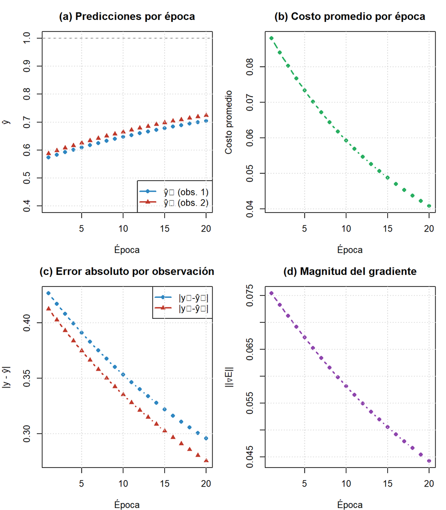

```r
par(mfrow = c(2, 2), mar = c(4, 4, 3, 1))

# (a) Predicciones por época
plot(hist_mat$Epoca, hist_mat$yhat1,
     type = "b", pch = 16, col = "#2E86C1", lwd = 2,
     ylim = range(c(hist_mat$yhat1, hist_mat$yhat2, 0.4, 1)),
     xlab = "Época", ylab = "ŷ",
     main = "(a) Predicciones por época")
lines(hist_mat$Epoca, hist_mat$yhat2,
      type = "b", pch = 17, col = "#C0392B", lwd = 2)
abline(h = 1, lty = 2, col = "gray50")
legend("bottomright",
       legend = c("ŷ₁ (obs. 1)", "ŷ₂ (obs. 2)"),
       col = c("#2E86C1","#C0392B"), pch = c(16,17), lwd = 2)
grid()

# (b) Costo
plot(hist_mat$Epoca, hist_mat$Costo,
     type = "b", pch = 16, col = "#27AE60", lwd = 2,
     xlab = "Época", ylab = "Costo promedio",
     main = "(b) Costo promedio por época")
grid()

# (c) Error absoluto
plot(hist_mat$Epoca, hist_mat$Err_abs1,
     type = "b", pch = 16, col = "#2E86C1", lwd = 2,
     ylim = range(c(hist_mat$Err_abs1, hist_mat$Err_abs2)),
     xlab = "Época", ylab = "|y - ŷ|",
     main = "(c) Error absoluto por observación")
lines(hist_mat$Epoca, hist_mat$Err_abs2,
      type = "b", pch = 17, col = "#C0392B", lwd = 2)
legend("topright",
       legend = c("|y₁-ŷ₁|", "|y₂-ŷ₂|"),
       col = c("#2E86C1","#C0392B"), pch = c(16,17), lwd = 2)
grid()

# (d) Magnitud del gradiente
plot(hist_mat$Epoca, hist_mat$Grad_mag,
     type = "b", pch = 16, col = "#8E44AD", lwd = 2,
     xlab = "Época", ylab = "||∇E||",
     main = "(d) Magnitud del gradiente")
grid()
```

```r
par(mfrow = c(1, 1))
```

> **Análisis:** Con dos observaciones (batch de tamaño 2), el gradiente se promedia sobre ambas, lo que produce actualizaciones más estables que con una sola observación. Ambas predicciones mejoran simultáneamente hacia el objetivo $y = 1$.

# Interpretación y comparación de los tres escenarios

```r
df_final <- data.frame(
  Escenario    = c("1 obs. (original)", "1 obs. (alt. init.)",
                   "2 obs. (matricial)"),
  yhat_ep1     = c(hist_orig$y_hat[1], hist_alt$y_hat[1],
                   (hist_mat$yhat1[1] + hist_mat$yhat2[1])/2),
  costo_ep1    = c(hist_orig$Costo[1], hist_alt$Costo[1],
                   hist_mat$Costo[1]),
  yhat_ep20    = c(hist_orig$y_hat[20], hist_alt$y_hat[20],
                   (hist_mat$yhat1[20] + hist_mat$yhat2[20])/2),
  costo_ep20   = c(hist_orig$Costo[20], hist_alt$Costo[20],
                   hist_mat$Costo[20])
)

knitr::kable(df_final,
  col.names = c("Escenario", "ŷ inicial", "Costo inicial",
                "ŷ final", "Costo final"),
  digits = 5,
  caption = "Comparación de los tres escenarios de entrenamiento")
```

Comparación de los tres escenarios de entrenamiento

| Escenario | ŷ inicial | Costo inicial | ŷ final | Costo final |
| --- | --- | --- | --- | --- |
| 1 obs. (original) | 0.57350 | 0.09095 | 0.70590 | 0.04325 |
| 1 obs. (alt. init.) | 0.49681 | 0.12660 | 0.66699 | 0.05545 |
| 2 obs. (matricial) | 0.58054 | 0.08800 | 0.71446 | 0.04082 |

> **Discusión:**

> **Número de observaciones:** Usar más observaciones por actualización proporciona un gradiente más representativo de la función de pérdida global, lo que suele producir convergencia más estable.

> **Inicialización:** Diferentes puntos de partida pueden llevar a trayectorias distintas. En redes pequeñas como esta, generalmente se alcanza la misma región del espacio de parámetros, pero la velocidad puede variar.

> **¿Por qué se necesita la capa oculta?** Sin la capa oculta, solo podemos aprender funciones lineales. XOR requiere una frontera no lineal que solo puede construirse combinando múltiples transformaciones lineales con funciones de activación no lineales.

> **Limitación de entrenar con solo 1 o 2 observaciones:** La red se especializa en esas observaciones y puede no generalizar bien a las otras. Esto se llama **sobreajuste parcial**. Para aprender XOR completo se necesitan las 4 observaciones.

## Reflexión conceptual — ¿Cómo aprende la red?

El proceso de aprendizaje de una red neuronal puede entenderse como un ciclo iterativo compuesto por varias etapas fundamentales.

### Esquema del proceso de aprendizaje

1. **Entrada:** Se introduce el vector de características $(x_1, x_2)$.
2. **Propagación hacia adelante (Forward pass):**  
   La red procesa la información a través de sus capas y genera una predicción $\hat{y}$.
3. **Cálculo del error:**  
   Se determina la diferencia entre el valor real y la predicción:

   $$error = y - \hat{y}$$
4. **Función de pérdida:**  
   Se cuantifica el error mediante la función:

   $$E = \frac{1}{2}(y - \hat{y})^2$$
5. **Retropropagación (Backpropagation):**  
   Se calculan los gradientes de la función de pérdida respecto a cada parámetro.
6. **Actualización de parámetros:**  
   Los pesos se ajustan mediante descenso de gradiente:

   $$w_i \leftarrow w_i - \alpha \frac{\partial E}{\partial w_i}$$
7. **Iteración:**  
   El proceso se repite durante múltiples épocas, mejorando progresivamente la predicción.

### Análisis del aprendizaje

La red neuronal aprende a partir de sus errores mediante los siguientes mecanismos:

- **Predicción ($\hat{y}$):**  
  Inicialmente, la red produce estimaciones alejadas del valor real debido a pesos aleatorios.
- **Error:**  
  La diferencia $(y - \hat{y})$ indica la magnitud y dirección del ajuste necesario.
- **Función de pérdida:**  
  Penaliza más los errores grandes, guiando el proceso de optimización.
- **Gradiente:**  
  Indica cómo debe modificarse cada peso para reducir la pérdida.
- **Retropropagación:**  
  Distribuye el error a través de la red, asignando responsabilidad a cada parámetro.
- **Actualización:**  
  Los pesos se ajustan en la dirección que minimiza el error.
- **Convergencia:**  
  Con suficientes iteraciones, el modelo mejora sus predicciones y se aproxima al comportamiento esperado.

### Análisis pedagógica

> Desde una perspectiva didáctica, este proceso permite comprender que el aprendizaje en redes neuronales no es inmediato >ni garantizado, sino el resultado de múltiples ajustes graduales.

> Cada iteración representa una mejora incremental basada en el error previo, lo que evidencia la importancia de:
> - La tasa de aprendizaje
> - La inicialización de los pesos
> - La arquitectura del modelo

> En conjunto, estos elementos determinan la capacidad de la red para aprender patrones complejos como la función XOR.

## Tabla XOR completa — Las 4 observaciones

### Concepto: Entrenamiento completo

Para que la red aprenda correctamente la función XOR, debe entrenarse con **todas las combinaciones posibles**:

$(0,0) \to 0$, $(0,1) \to 1$, $(1,0) \to 1$, $(1,1) \to 0$.

En esta sección se entrena durante 500 épocas para observar la convergencia del modelo.

```r
# ============================================================
# ENTRENAMIENTO CON LAS 4 OBSERVACIONES XOR
# ============================================================

entrenar_xor_completo <- function(
    X, y,
    W1_0, W2_0, b1_0 = c(0,0), b2_0 = 0,
    alpha = 0.5, n_epocas = 500
) {

  W1 <- W1_0; W2 <- W2_0; b1 <- b1_0; b2 <- b2_0
  n <- nrow(X)
  historial <- data.frame()

  for (ep in 1:n_epocas) {

    # Forward
    Z1 <- sweep(X %*% W1, 2, b1, "+")
    H1 <- sigmoid(Z1)
    Z2 <- H1 %*% W2 + b2
    Yhat <- sigmoid(Z2)

    E <- mean(0.5 * (y - Yhat)^2)

    # Backprop
    delta2 <- (Yhat - y) * sigmoid_deriv(Yhat)
    dW2 <- t(H1) %*% delta2 / n
    db2 <- mean(delta2)

    delta1 <- (delta2 %*% t(W2)) * sigmoid_deriv(H1)
    dW1 <- t(X) %*% delta1 / n
    db1 <- colMeans(delta1)

    # Actualización
    W1 <- W1 - alpha * dW1
    W2 <- W2 - alpha * dW2
    b1 <- b1 - alpha * db1
    b2 <- b2 - alpha * db2

    if (ep %% 50 == 0 || ep == 1) {
      historial <- rbind(historial, data.frame(
        Epoca    = ep,
        Costo    = round(E, 6),
        yhat_00  = round(Yhat[1], 4),
        yhat_01  = round(Yhat[2], 4),
        yhat_10  = round(Yhat[3], 4),
        yhat_11  = round(Yhat[4], 4)
      ))
    }
  }

  list(historial = historial, W1 = W1, W2 = W2,
       b1 = b1, b2 = b2,
       Yhat_final = Yhat)
}

# Las 4 observaciones XOR
X_full <- matrix(c(0,0, 0,1, 1,0, 1,1), nrow=4, byrow=TRUE)
y_full <- matrix(c(0, 1, 1, 0), nrow=4)

cat("Tabla XOR completa:\n")
```

```
## Tabla XOR completa:
```

```r
cat("x1  x2  y\n")
```

```
## x1  x2  y
```

```r
for(i in 1:4) cat(X_full[i,1], X_full[i,2], y_full[i], "\n")
```

```
## 0 0 0
## 0 1 1
## 1 0 1
## 1 1 0
```

```r
# Inicialización con pesos pequeños aleatorios (semilla fija)
set.seed(123)
W1_full <- matrix(rnorm(4, 0, 0.5), nrow=2)
W2_full <- matrix(rnorm(2, 0, 0.5), nrow=2)

resultado <- entrenar_xor_completo(
  X = X_full, y = y_full,
  W1_0 = W1_full, W2_0 = W2_full,
  alpha = 0.5, n_epocas = 500
)
```

## Tabla de evolución cada 50 épocas

```r
knitr::kable(resultado$historial,
  col.names = c("Época", "Costo", "ŷ(0,0)", "ŷ(0,1)", "ŷ(1,0)", "ŷ(1,1)"),
  digits = 5,
  caption = "Entrenamiento XOR completo: evolución cada 50 épocas")
```

Entrenamiento XOR completo: evolución cada 50 épocas

| Época | Costo | ŷ(0,0) | ŷ(0,1) | ŷ(1,0) | ŷ(1,1) |
| --- | --- | --- | --- | --- | --- |
| 1 | 0.13382 | 0.6133 | 0.6146 | 0.6492 | 0.6503 |
| 50 | 0.12517 | 0.4953 | 0.4969 | 0.5266 | 0.5281 |
| 100 | 0.12509 | 0.4847 | 0.4869 | 0.5148 | 0.5169 |
| 150 | 0.12508 | 0.4838 | 0.4866 | 0.5135 | 0.5160 |
| 200 | 0.12506 | 0.4838 | 0.4872 | 0.5129 | 0.5160 |
| 250 | 0.12505 | 0.4838 | 0.4877 | 0.5125 | 0.5160 |
| 300 | 0.12504 | 0.4838 | 0.4883 | 0.5121 | 0.5161 |
| 350 | 0.12502 | 0.4837 | 0.4889 | 0.5117 | 0.5162 |
| 400 | 0.12501 | 0.4837 | 0.4894 | 0.5114 | 0.5164 |
| 450 | 0.12499 | 0.4836 | 0.4899 | 0.5110 | 0.5165 |
| 500 | 0.12498 | 0.4835 | 0.4904 | 0.5107 | 0.5167 |

## Predicciones finales y clasificación

```r
Yhat_final <- resultado$Yhat_final
pred_clase  <- ifelse(Yhat_final >= 0.5, 1, 0)

df_pred <- data.frame(
  x1        = X_full[,1],
  x2        = X_full[,2],
  y_real    = as.integer(y_full),
  y_hat     = round(Yhat_final, 4),
  clase_pred = pred_clase,
  correcto  = ifelse(pred_clase == y_full, "✓", "✗")
)

knitr::kable(df_pred,
  col.names = c("x₁","x₂","y real","ŷ","Clase predicha","¿Correcto?"),
  caption = "Predicciones finales de la red XOR completa")
```

Predicciones finales de la red XOR completa

| x₁ | x₂ | y real | ŷ | Clase predicha | ¿Correcto? |
| --- | --- | --- | --- | --- | --- |
| 0 | 0 | 0 | 0.4835 | 0 | ✓ |
| 0 | 1 | 1 | 0.4904 | 0 | ✗ |
| 1 | 0 | 1 | 0.5107 | 1 | ✓ |
| 1 | 1 | 0 | 0.5167 | 1 | ✗ |

```r
acc <- mean(pred_clase == y_full) * 100
cat(sprintf("\nPrecisión final: %.1f%%\n", acc))
```

```
##
## Precisión final: 50.0%
```